# How to formalize a verbal theory with VAST

Visual Argument Structure Tool (VAST) by Leising, Grenke & Cramer

Daniel Leising

Daniel.Leising@tu-dresden.de

Technical University Dresden

Felix Schönbrodt

felix.schoenbrodt@psy.lmu.de

Ludwig-Maximilians-Universität München

2023-11-17

## Where do theories come from?

- Falsificationism starts with a (tentative) theory, which is repeatedly tested, refuted, and refined.
- But where does the initial theory come from? “Flair”? Flash of inspiration in the shower?
- Popper did not care much about the first stage of creating theories - just about the later testing of theories.

**Conjecture**: We have a refined methodology¹ to *test* theories (e.g., experimental designs, statistical methods, preregistration, …). But we had (so far) no good methodology for constructing theories.

¹ “A scientific methodology is an ordered series of steps that assist a researcher in reaching a desired end state from a specified starting point.” (Borsboom et al., 2021)

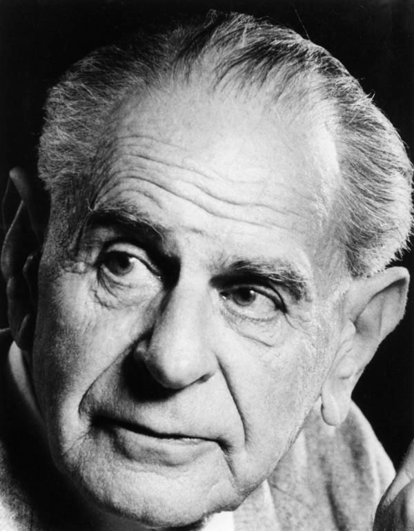

Sir Karl Popper, 1902 - 1994

# Visual Argument Structure Tool (VAST) V1.0

Leising, D., Grenke, O., & Cramer, M. (2023). Visual Argument Structure Tool (VAST) Version 1.0. Meta-Psychology, 7. https://doi.org/10.15626/MP.2021.2911

## Introduction

This is a brief introduction into some of the core features of VAST. In doing this, I will simplify a few features and ignore others completely.

## Types of elements (selection)

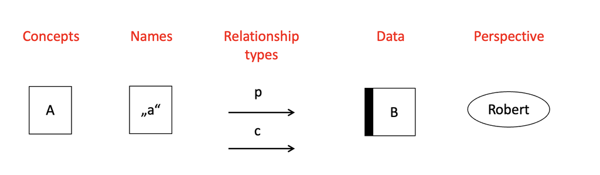

## Arrows stand for IF-THEN relationships

### If X, THEN Y

Six types of relationships:

- naming (**n**)
- conceptual implication (**i**)
- causation (**c**)
- prediction (**p**)
- transformation (**t**)
- reasoning (**r**)

## Naming concepts

### Synonyms

[figure not shown]

A concept may have any number of names. Here, all three names are synonyms regarding concept `I`.

## Naming concepts

### Homonyms

[figure not shown]

This expresses the idea that the same name is used for conditions that may not be the same. This name might thus be a **homonym.**

## Naming concepts

### Visualizing a jingle-jangle situation

[figure not shown]

- “Big” = jingle for `F` and `T`
- “Big” and “Famous” = jangle for `F`

## Data

[figure not shown]

- **Data** (left box, folder-shaped) is a special kind of concept, which explicitly refers to something observable.
  - Same as a manifest variable in Structural Equation Modeling
- This display is supposed to capture the idea that “Intelligence is what the intelligence test measures”

## Data

### Symbol

Note: In the original VAST paper, the Data concept has a different shape (but that shape is not available in the Graphviz system used to create these graphs):

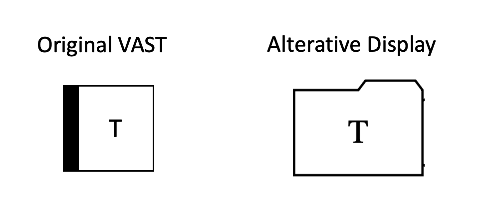

## Data

[figure not shown]

- The `r` denotes *reasoning* relationships
- This display is supposed to capture the idea that more than one test may be used as evidence for people‘s intelligence

## Data

[figure not shown]

- The `p` stands for a prediction
- The `c` stands for causal effects

## Data

[figure not shown]

This display is supposed to capture the idea that …

- The same thing has a causal effect on the outcomes of both tests
- Therefore, the outcomes of the two tests correlate with one another

## Splitting up the display elements

[figure not shown]

Readability may often be promoted by setting naming relationships aside.

## Splitting up the display elements

[figure not shown]

## Fuzziness

- The goal are *precise* theories - but in reality, they often are (at least partially) vague and fuzzy
- VAST allows to make this fuzziness explicit by allowing vague quantifiers of relationship strength, e.g. “weakly positive”, “strong”
  - Better than assigning an arbitrary, pseudo-precise number
  - It’s about formalizing the current state/precision of a verbal theory - if it is imprecise, let’s show it!
- Show gaps and underspecifications

## Notes on the different types of relationships

- Relationships between constructs can be …
  - on a theoretical level. Then it’s typically a causal path (c)
  - on empirical level: A relationship has been found! This is a prediction path (p)
  - Research cycle: One author’s p-path is the next author’s theoretical c-path
- Consider what you want to formalize:
  - A certain author’s theoretical point of view at a certain point in time?
  - Or your personal, current point of view?
  - The empirical support for a statement?

## Theory vs. Model

In order to translate a theory into a model, one needs to …

- give a scale to every variable (e.g. by defining it’s measurement/operationalization)

# Steps to formalize an existing verbal theory

## Step 1: Choose your starting point

Formalization approaches can differ in their *starting point* (which often are not clear-cut distinct):

## Step 2: Limit your scope

Most theories in psychology are too fuzzy and broad to be formalized in one go. Limit your scope:

- Limit the number of **constructs** and their **relationships**: Start with a small number of constructs, and add complexity later.
- Limit the number of **phenomena** that your model is supposed to explain.

## Step 3: Collect definitions of constructs, with reference to the literature.

- Collect definitions of constructs and relationships from the literature.
- Make them atomic (i.e., split up long quotes into their basic components).
- Assign a unique ID to each statement

This table will be called the “Definitions”

| ID | Construct Label | Quote | Reference | VAST type (n, p, i, r, …) | Comment |
| --- | --- | --- | --- | --- | --- |
| A |  |  |  |  |  |
| B |  |  |  |  |  |
| … |  |  |  |  |  |

## Step X: Choose a specific formalization

“Diffusion of responsibility” (Darley & Latané, 1968): The presence of others reduces the likelihood of helping behavior in emergencies.

But how is it reduced exactly? (see Forsyth et al., 2002):

- Linear relationship?
- A reduction in personal responsibility as groups increase in size but an eventual leveling off in larger groups?
- Where does responsibility go when it diffuses in the group? Does it diffuse equally, with each member getting an equal portion, or is it concentrated on certain individuals?

E.g., Forsyth et al. ([2002](https://journals.sagepub.com/doi/10.1177/0146167202281005))

# End

## Contact

- [@nicebread@scicomm.xyz](https://scicomm.xyz/@nicebread)
- ed.uml.ysp@tdorbneohcs.xilef
- https://www.nicebread.de
- https://github.com/nicebread

CC-BY-SA 4.0

Formal modeling in psychology - Empirisches Praktikum, Ludwig-Maximilians-Universität München